# Queuing_envelope_mg1

2024-04-24

# Approximating Queuing Delay from M/GI/1 to M/M/1 Envelope

## FUNCTIONS

### Function for Calculating of M/M/1 envelope load for M/G/1

```r
envelope_load_calc <- function(Capacity_Gbps, k_num, Load, PS_size, PS_weights)
{
  mg1_packets <- simmer_mg1(Capacity_Gbps, Load, PS_size, PS_weights, k_num = 1e4)
  cat("Load real M/G/1:", Load, "\n")

  # Step 1: Determine the average delay (E(T))
  E_T_real <- mean(mg1_packets)
  N = sum(PS_size*PS_weights)
  N
  var_N <- sum(PS_size^2*PS_weights) - N^2
  Cs2 <- var_N/(N^2)
  nodes_capacity_Bps = Capacity_Gbps*1e9
  Capacity_ps = nodes_capacity_Bps/(8*N)
  E_X = 1/Capacity_ps

  percentiles_seq <- seq(0.5, 0.99, 0.01)

  n = 1
  df_real <- sapply(percentiles_seq, function(x) quantile(mg1_packets, x))*1e6 #real
  rho_env = seq(from=0.01,to=0.99,by=0.01)
  for (rho in rho_env){
    df_env <- qexp(percentiles_seq,rate = ((1-rho)/E_X))*1e6 # mu s
    if (all(df_real < df_env)){
      cat("Envelope upper bound \n")
      cat("Load Envelope:", rho, "\n")
      cat("E(T) exponential envelope M/M/1:", E_X/(1-rho), "s \n")
      cat("E(T) Real M/GI/1:", E_T_real, "s \n")
      cat("\n")
      break
    }
    n = n + 1
  }
  return(rho)
}
```

## INPUT DATA

```r
Capacity_Gbps = 10
k_num = 1e4 #number of simulation packages
Load <- 0.7  # Load
# #V1
PS_size <- c(40, 576, 1500)  # Packet sizes in bytes
PS_weights <- c(7, 4, 1) / 12  # Packet weights
```

# Part 1: simulation M/G/1 and envelope M/M/1 calculations

## SIMULATION

```r
mg1_packets <- simmer_mg1(Capacity_Gbps, Load, PS_size, PS_weights, k_num = 1e4)
```

## M/G/1 calculations of parameters

```r
real_cdf <- ecdf(mg1_packets)
cat("Load real M/G/1:", Load, "\n")
```

```
## Load real M/G/1: 0.7
```

```r
# Step 1: Determine the average delay (E(T))
E_T_real <- mean(mg1_packets)
N = sum(PS_size*PS_weights)
N
```

```
## [1] 340.3333
```

```r
var_N <- sum(PS_size^2*PS_weights) - N^2
Cs2 <- var_N/(N^2)
nodes_capacity_Bps = Capacity_Gbps*1e9
Capacity_ps = nodes_capacity_Bps/(8*N)
E_X = 1/Capacity_ps
```

## Envelope M/M/1 fitting process

Envelope E(T) M/M/1 should be above real M/G/1 for percentiles from 50% - 99%

```r
percentiles_seq <- seq(0.5, 0.99, 0.01)

n = 1
df_real <- sapply(percentiles_seq, function(x) quantile(mg1_packets, x))*1e6 #real
rho_env = seq(from=0.01,to=0.99,by=0.01)
for (rho in rho_env){
  df_env <- qexp(percentiles_seq,rate = ((1-rho)/E_X))*1e6 # mu s
  if (all(df_real < df_env)){
    cat("Envelope upper bound \n")
    cat("Load Envelope:", rho, "\n")
    cat("E(T) exponential envelope M/M/1:", E_X/(1-rho), "s \n")
    cat("E(T) Real M/GI/1:", E_T_real, "s \n")
    break
  }
  n = n + 1
}
```

```
## Envelope upper bound
## Load Envelope: 0.77
## E(T) exponential envelope M/M/1: 1.183768e-06 s
## E(T) Real M/GI/1: 1.069956e-06 s
```

```r
rho_env = rho
envelope_rate = (1-rho)/E_X
```

## Plots

PDF of real and envelope

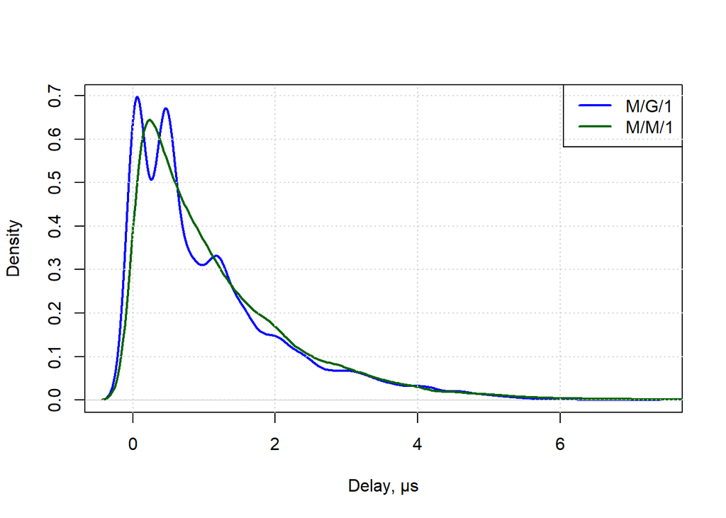

```r
plot(density(mg1_packets*1e6), col = "blue", main = "", xlab = "Delay, μs", lwd = 2)
lines(density(rexp(1e4, rate = envelope_rate)*1e6), col = "darkgreen", lwd = 2)
legend("topright", legend = c("M/G/1", "M/M/1"), col = c("blue", "darkgreen"), lwd = 2)
grid()
```

Plot the percentiles of real and envelope

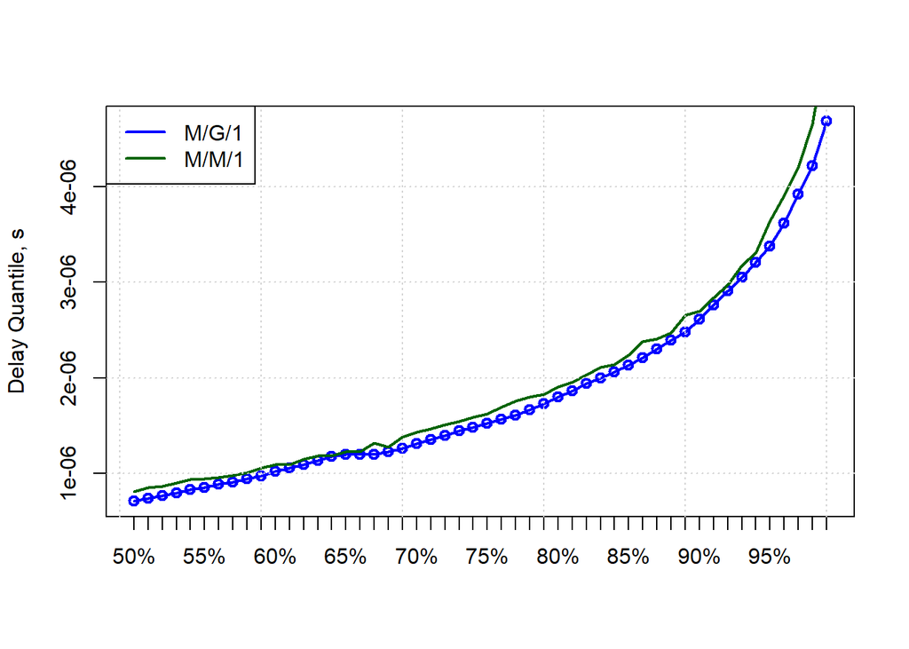

```r
df_real <- sapply(percentiles_seq, function(x) quantile(mg1_packets, x))
df_env <- sapply(percentiles_seq, function(x) quantile(rexp(1e4, rate = envelope_rate), x))

# Plot with no additional x-axis labels
plot(df_real, col = "blue", xlab = "", ylab = "Delay Quantile, s", main = "", xaxt = "n", lwd = 2)
lines(df_real, col = "blue", lwd = 2)
lines(df_env, col = "darkgreen", lwd = 2)

# Add x-axis labels for percentiles_seq
axis(1, at = seq_along(percentiles_seq), labels = paste0(percentiles_seq * 100, "%"))
legend("topleft", legend = c("M/G/1", "M/M/1"), col = c("blue", "darkgreen"), lwd = 2)
grid()
```

Plot the log CCDF

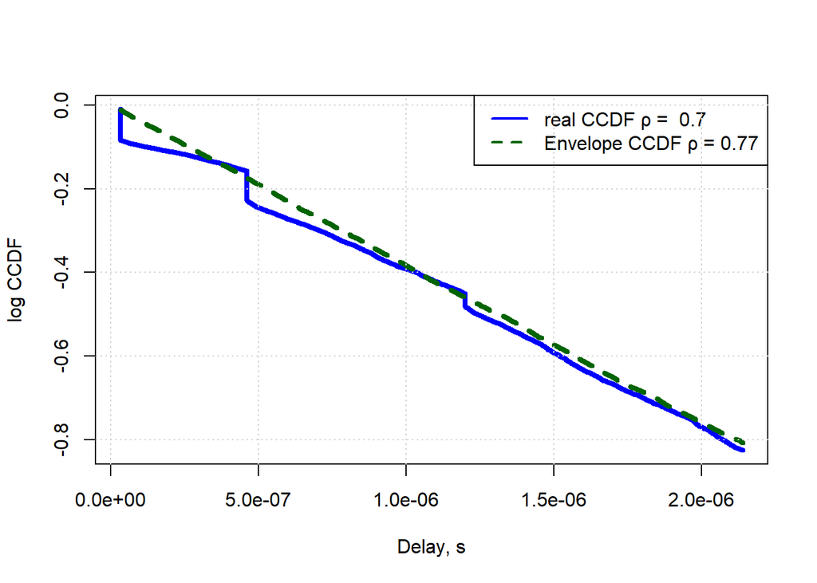

```r
t_min = min(mg1_packets)
t_max = 2*E_T_real
# Compute the empirical CDF
ecdf_values <- ecdf(mg1_packets)
# Generate x values for the plot E(T)
x_values <- seq(t_min, t_max, length.out = 1e4)
# Compute the empirical CDF values
ecdf_y_values_sim <- ecdf_values(x_values)


envelope_ecdf_val <- envelope_cdf(envelope_rate)
ecdf_y_values_env_upper_bound <- envelope_ecdf_val(x_values)


lwd = 4
plot(x_values, log10(1 - ecdf_y_values_sim), type = "l", xlab = "Delay, s", ylab = "log CCDF", main = "", col = "blue", lwd = lwd)
lines(x_values, log10(1 - ecdf_y_values_env_upper_bound), col = "darkgreen", lty = 2, lwd  = lwd )
legend("topright", legend = c(paste("real CCDF ρ = ", Load),
                             paste("Envelope CCDF ρ =", round(rho_env, 2))),
      col = c("blue", "darkgreen" ), lty = c(1, 2), lwd = 2)

grid()
```

# Part 2: finding polinomial regression/relationship between load_real and load_envelope

```r
# Data
loads_real <- seq(0.01, 0.99, 0.01)
loads_envelope <- sapply(loads_real, function(load) envelope_load_calc(Capacity_Gbps, k_num, load, PS_size, PS_weights))
```

```
## Load real M/G/1: 0.01
## Envelope upper bound
## Load Envelope: 0.49
## E(T) exponential envelope M/M/1: 5.338562e-07 s
## E(T) Real M/GI/1: 2.824983e-07 s
##
## Load real M/G/1: 0.02
## Envelope upper bound
## Load Envelope: 0.48
## E(T) exponential envelope M/M/1: 5.235897e-07 s
## E(T) Real M/GI/1: 2.785732e-07 s
##
## Load real M/G/1: 0.03
## Envelope upper bound
## Load Envelope: 0.49
## E(T) exponential envelope M/M/1: 5.338562e-07 s
## E(T) Real M/GI/1: 2.823481e-07 s
##
## Load real M/G/1: 0.04
## Envelope upper bound
## Load Envelope: 0.48
## E(T) exponential envelope M/M/1: 5.235897e-07 s
## E(T) Real M/GI/1: 2.850714e-07 s
##
## Load real M/G/1: 0.05
## Envelope upper bound
## Load Envelope: 0.49
## E(T) exponential envelope M/M/1: 5.338562e-07 s
## E(T) Real M/GI/1: 2.943641e-07 s
##
## Load real M/G/1: 0.06
## Envelope upper bound
## Load Envelope: 0.49
## E(T) exponential envelope M/M/1: 5.338562e-07 s
## E(T) Real M/GI/1: 2.932052e-07 s
##
## Load real M/G/1: 0.07
## Envelope upper bound
## Load Envelope: 0.52
## E(T) exponential envelope M/M/1: 5.672222e-07 s
```

[output cut: 538 more lines]

```
## Load Envelope: 0.99
## E(T) exponential envelope M/M/1: 2.722667e-05 s
## E(T) Real M/GI/1: 1.706911e-05 s
##
## Load real M/G/1: 0.98
## Envelope upper bound
## Load Envelope: 0.97
## E(T) exponential envelope M/M/1: 9.075556e-06 s
## E(T) Real M/GI/1: 6.848687e-06 s
##
## Load real M/G/1: 0.99
## Envelope upper bound
## Load Envelope: 0.98
## E(T) exponential envelope M/M/1: 1.361333e-05 s
## E(T) Real M/GI/1: 8.242209e-06 s
```

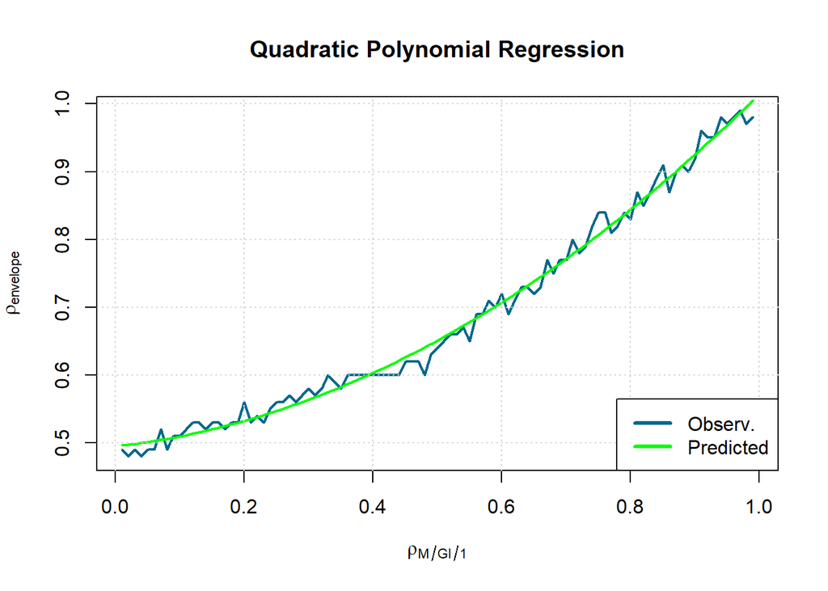

```r
# Fitting a quadratic polynomial regression model
model <- lm(loads_envelope ~ poly(loads_real, 2, raw = TRUE))

# Generating sequence of loads_real values for prediction
load_real_pred <- seq(min(loads_real), max(loads_real), length.out = 100)

# Predicting loads_envelope values for the generated loads_real values
load_envelope_pred <- predict(model, newdata = data.frame(loads_real = load_real_pred))

# Plotting the observed data and the predicted values
plot(loads_real, loads_envelope, type = 'l', col = 'deepskyblue4', xlab = expression(rho[M/GI/1]), ylab = expression(rho[envelope]), main = 'Quadratic Polynomial Regression', lwd = 2)
lines(load_real_pred, load_envelope_pred, col = 'green', lwd = 2)
grid()
legend("bottomright",c("Observ.","Predicted"),
       col=c("deepskyblue4","green"), lwd=3)
```

Extract the coefficients from the fitted quadratic polynomial regression model:

```r
# Extract the coefficients of the fitted model
coef_model <- coef(model)

# Construct the formula
formula <- paste0("y(x) = ", coef_model[1], " + ", coef_model[2], "x",
                  " + ", coef_model[3], "x^2")

# Print the formula
print(formula)
```

```
## [1] "y(x) = 0.495076347314934 + 0.105061982739405x + 0.414096953562388x^2"
```

# Part 3: Checking the polinomial prediction

```r
loads_real = 0.57
cat("Load real M/G/1:", loads_real, "\n")
```

```
## Load real M/G/1: 0.57
```

```r
mg1_packets <- simmer_mg1(Capacity_Gbps, loads_real, PS_size, PS_weights, k_num = 1e4)


load_envelope_predicted = predict(model, newdata = data.frame(loads_real))


n = 1
df_real <- sapply(percentiles_seq, function(x) quantile(mg1_packets, x))*1e6 #real
rho_env = seq(from=0.01,to=0.99,by=0.01)

df_env <- qexp(percentiles_seq,rate = ((1-load_envelope_predicted)/E_X))*1e6 # mu s
cat("All quantiles df_real are below envelope:", all(df_real < df_env), "\n")
```

```
## All quantiles df_real are below envelope: TRUE
```

```r
cat("Envelope upper bound \n")
```

```
## Envelope upper bound
```

```r
cat("Load envelope M/M/1:", load_envelope_predicted, "\n")
```

```
## Load envelope M/M/1: 0.6895018
```

```r
cat("E(T) exponential envelope M/M/1:", E_X/(1-load_envelope_predicted), "s \n")
```

```
## E(T) exponential envelope M/M/1: 8.768703e-07 s
```

```r
cat("E(T) Real M/GI/1:", mean(mg1_packets), "s \n")
```

```
## E(T) Real M/GI/1: 7.412351e-07 s
```

```r
print(paste0("Envelope load obtained from polynomial: ", formula,"=",coef_model[1] +coef_model[2]*loads_real + coef_model[3]*loads_real^2))
```

```
## [1] "Envelope load obtained from polynomial: y(x) = 0.495076347314934 + 0.105061982739405x + 0.414096953562388x^2=0.689501777688815"
```

# Part 4:

## Polynomial prediction for different packet size distributions

```r
# Data
#V1
PS_size <- c(40, 576, 1500)  # Packet sizes in bytes
PS_weights <- c(7, 4, 1) / 12  # Packet weights
loads_real <- seq(0.01, 0.99, 0.01)

loads_envelope_v1 <- sapply(loads_real, function(load) envelope_load_calc(Capacity_Gbps, k_num, load, PS_size, PS_weights))
```

```
## Load real M/G/1: 0.01
## Envelope upper bound
## Load Envelope: 0.49
## E(T) exponential envelope M/M/1: 5.338562e-07 s
## E(T) Real M/GI/1: 2.791413e-07 s
##
## Load real M/G/1: 0.02
## Envelope upper bound
## Load Envelope: 0.48
## E(T) exponential envelope M/M/1: 5.235897e-07 s
## E(T) Real M/GI/1: 2.745303e-07 s
##
## Load real M/G/1: 0.03
## Envelope upper bound
## Load Envelope: 0.48
## E(T) exponential envelope M/M/1: 5.235897e-07 s
## E(T) Real M/GI/1: 2.843341e-07 s
##
## Load real M/G/1: 0.04
## Envelope upper bound
## Load Envelope: 0.49
## E(T) exponential envelope M/M/1: 5.338562e-07 s
## E(T) Real M/GI/1: 2.860208e-07 s
##
## Load real M/G/1: 0.05
## Envelope upper bound
## Load Envelope: 0.49
## E(T) exponential envelope M/M/1: 5.338562e-07 s
## E(T) Real M/GI/1: 2.834616e-07 s
##
## Load real M/G/1: 0.06
## Envelope upper bound
## Load Envelope: 0.49
## E(T) exponential envelope M/M/1: 5.338562e-07 s
## E(T) Real M/GI/1: 2.946321e-07 s
##
## Load real M/G/1: 0.07
## Envelope upper bound
## Load Envelope: 0.51
## E(T) exponential envelope M/M/1: 5.556463e-07 s
```

[output cut: 538 more lines]

```
## Load Envelope: 0.97
## E(T) exponential envelope M/M/1: 9.075556e-06 s
## E(T) Real M/GI/1: 6.667481e-06 s
##
## Load real M/G/1: 0.98
## Envelope upper bound
## Load Envelope: 0.97
## E(T) exponential envelope M/M/1: 9.075556e-06 s
## E(T) Real M/GI/1: 7.719119e-06 s
##
## Load real M/G/1: 0.99
## Envelope upper bound
## Load Envelope: 0.99
## E(T) exponential envelope M/M/1: 2.722667e-05 s
## E(T) Real M/GI/1: 1.950163e-05 s
```

```r
# Fitting a quadratic polynomial regression model
model_v1 <- lm(loads_envelope_v1 ~ poly(loads_real, 2, raw = TRUE))

# Generating sequence of loads_real values for prediction
load_real_pred <- seq(min(loads_real), max(loads_real), length.out = 100)

# Predicting loads_envelope values for the generated loads_real values
load_envelope_pred_v1 <- predict(model_v1, newdata = data.frame(loads_real = load_real_pred))

#V2 https://www.ams-ix.net/ams
PS_size=c((64+127)/2,(128+255)/2,(256+511)/2, (512+1023)/2, (1024+1513)/2, 1514, (1515+9100)/2)
PS_weights=c(33.2/100, 5.4/100, 3.3/100, 3.7/100, 34.6/100, 14.6/100, 5.2/100)
loads_envelope_v2 <- sapply(loads_real, function(load) envelope_load_calc(Capacity_Gbps, k_num, load, PS_size, PS_weights))
```

```
## Load real M/G/1: 0.01
## Envelope upper bound
## Load Envelope: 0.45
## E(T) exponential envelope M/M/1: 1.482233e-06 s
## E(T) Real M/GI/1: 8.205311e-07 s
##
## Load real M/G/1: 0.02
## Envelope upper bound
## Load Envelope: 0.45
## E(T) exponential envelope M/M/1: 1.482233e-06 s
## E(T) Real M/GI/1: 8.574681e-07 s
##
## Load real M/G/1: 0.03
## Envelope upper bound
## Load Envelope: 0.45
## E(T) exponential envelope M/M/1: 1.482233e-06 s
## E(T) Real M/GI/1: 8.411308e-07 s
##
## Load real M/G/1: 0.04
## Envelope upper bound
## Load Envelope: 0.45
## E(T) exponential envelope M/M/1: 1.482233e-06 s
## E(T) Real M/GI/1: 8.698631e-07 s
##
## Load real M/G/1: 0.05
## Envelope upper bound
## Load Envelope: 0.45
## E(T) exponential envelope M/M/1: 1.482233e-06 s
## E(T) Real M/GI/1: 8.607107e-07 s
##
## Load real M/G/1: 0.06
## Envelope upper bound
## Load Envelope: 0.45
## E(T) exponential envelope M/M/1: 1.482233e-06 s
## E(T) Real M/GI/1: 8.897541e-07 s
##
## Load real M/G/1: 0.07
## Envelope upper bound
## Load Envelope: 0.45
## E(T) exponential envelope M/M/1: 1.482233e-06 s
```

[output cut: 538 more lines]

```
## Load Envelope: 0.97
## E(T) exponential envelope M/M/1: 2.717427e-05 s
## E(T) Real M/GI/1: 2.091181e-05 s
##
## Load real M/G/1: 0.98
## Envelope upper bound
## Load Envelope: 0.98
## E(T) exponential envelope M/M/1: 4.07614e-05 s
## E(T) Real M/GI/1: 2.797093e-05 s
##
## Load real M/G/1: 0.99
## Envelope upper bound
## Load Envelope: 0.99
## E(T) exponential envelope M/M/1: 8.15228e-05 s
## E(T) Real M/GI/1: 3.97279e-05 s
```

```r
model_v2 <- lm(loads_envelope_v2 ~ poly(loads_real, 2, raw = TRUE))
load_envelope_pred_v2 <- predict(model_v2, newdata = data.frame(loads_real = load_real_pred))

#V3 https://www.seattleix.net/statistics/
# PS_size=c((64), (65+128)/2, (129+256)/2,(257+384)/2, (385+512)/2,(513+640)/2,(641+768)/2,(769+896)/2,
#           (897+1024)/2,
#           (1025+1152)/2,(1153+1280)/2,(1515+1408)/2,(1409+1536)/2, (1537+9999)/2)
# PS_weights = c(4.2, 22.73, 4.79,1.93,0.92, 1.04, 0.74, 0.49, 0.45, 0.82, 6.56,9.30, 45.95, 0.07)
# PS_weights = PS_weights/100

# #V4 San Francisco Metropolitan Internet Exchange (SFMIX) https://grafana.sfmix.org/public-dashboards/7dedd014679f4c798124748a24e9f5ef?orgId=1&from=now-2d&to=now
PS_size=c(64,
          (65+127)/2,
          (128+255)/2,
          (256+511)/2,
          (513+1023)/2,
          (1024+1517)/2,
          (1518+9999)/2)
PS_weights = c(2, 23, 5, 5, 5, 40, 20)
PS_weights=PS_weights/100

loads_envelope_v3 <- sapply(loads_real, function(load) envelope_load_calc(Capacity_Gbps, k_num, load, PS_size, PS_weights))
```

```
## Load real M/G/1: 0.01
## Envelope upper bound
## Load Envelope: 0.52
## E(T) exponential envelope M/M/1: 2.91735e-06 s
## E(T) Real M/GI/1: 1.430262e-06 s
##
## Load real M/G/1: 0.02
## Envelope upper bound
## Load Envelope: 0.52
## E(T) exponential envelope M/M/1: 2.91735e-06 s
## E(T) Real M/GI/1: 1.435638e-06 s
##
## Load real M/G/1: 0.03
## Envelope upper bound
## Load Envelope: 0.5
## E(T) exponential envelope M/M/1: 2.800656e-06 s
## E(T) Real M/GI/1: 1.41856e-06 s
##
## Load real M/G/1: 0.04
## Envelope upper bound
## Load Envelope: 0.52
## E(T) exponential envelope M/M/1: 2.91735e-06 s
## E(T) Real M/GI/1: 1.456827e-06 s
##
## Load real M/G/1: 0.05
## Envelope upper bound
## Load Envelope: 0.5
## E(T) exponential envelope M/M/1: 2.800656e-06 s
## E(T) Real M/GI/1: 1.455549e-06 s
##
## Load real M/G/1: 0.06
## Envelope upper bound
## Load Envelope: 0.52
## E(T) exponential envelope M/M/1: 2.91735e-06 s
## E(T) Real M/GI/1: 1.49166e-06 s
##
## Load real M/G/1: 0.07
## Envelope upper bound
## Load Envelope: 0.52
## E(T) exponential envelope M/M/1: 2.91735e-06 s
```

[output cut: 534 more lines]

```
## E(T) Real M/GI/1: 4.211407e-05 s
##
## Load real M/G/1: 0.97
## Envelope upper bound
## Load Envelope: 0.98
## E(T) exponential envelope M/M/1: 7.00164e-05 s
## E(T) Real M/GI/1: 4.08052e-05 s
##
## Load real M/G/1: 0.98
## Envelope upper bound
## Load Envelope: 0.99
## E(T) exponential envelope M/M/1: 0.0001400328 s
## E(T) Real M/GI/1: 8.00865e-05 s
##
## Load real M/G/1: 0.99
```

```r
model_v3 <- lm(loads_envelope_v3 ~ poly(loads_real, 2, raw = TRUE))
load_envelope_pred_v3 <- predict(model_v3, newdata = data.frame(loads_real = load_real_pred))
```

# Part 5: Envelope load obtained from polynomial v1,v2,v3

V1 c(40, 576, 1500)

```r
# Extract the coefficients of the fitted model
coef_model_v1 <- coef(model_v1)
# Construct the formula
formula <- paste0("y(x) = ", coef_model_v1[1], " + ", coef_model_v1[2], "x",
                  " + ", coef_model_v1[3], "x^2")
# Print the formula
print(formula)
```

```
## [1] "y(x) = 0.492697817646271 + 0.130611738640727x + 0.385492157463169x^2"
```

Calculating RMSE (Root Mean Square Error) and R-squared for V1:

```r
rmse_v1 <- sqrt(mean((loads_envelope_v1 - predict(model_v1))^2))
r2_v1 <- summary(model_v1)$r.squared
```

V2 AMS-IX Amsterdam https://www.ams-ix.net/ams

```r
# Extract the coefficients of the fitted model
coef_model_v2 <- coef(model_v2)
# Construct the formula
formula <- paste0("y(x) = ", coef_model_v2[1], " + ", coef_model_v2[2], "x",
                  " + ", coef_model_v2[3], "x^2")
# Print the formula
print(formula)
```

```
## [1] "y(x) = 0.429221799310165 + 0.134194298874449x + 0.465187271935694x^2"
```

Calculating RMSE and R-squared for V2:

```r
rmse_v2 <- sqrt(mean((loads_envelope_v2 - predict(model_v2))^2))
r2_v2 <- summary(model_v2)$r.squared
```

V3 San Francisco Metropolitan Internet Exchange (SFMIX)

```r
# Extract the coefficients of the fitted model
coef_model_v3 <- coef(model_v3)
# Construct the formula
formula <- paste0("y(x) = ", coef_model_v3[1], " + ", coef_model_v3[2], "x",
                  " + ", coef_model_v3[3], "x^2")
# Print the formula
print(formula)
```

```
## [1] "y(x) = 0.501432715541699 + 0.160897759458251x + 0.343344664784173x^2"
```

Calculating RMSE and R-squared for V3:

```r
rmse_v3 <- sqrt(mean((loads_envelope_v3 - predict(model_v3))^2))
r2_v3 <- summary(model_v3)$r.squared
```

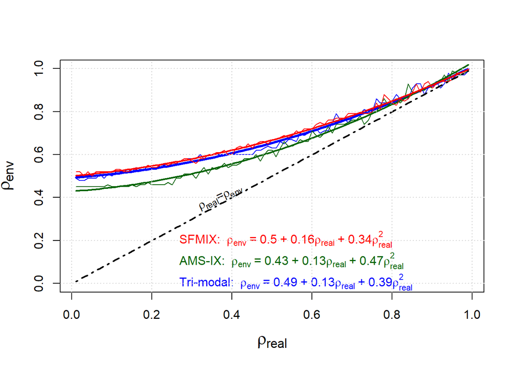

```r
loads_real <- seq(0.01, 0.99, 0.01)

plot(load_real_pred, load_envelope_pred_v1, type = 'l', col = 'blue', xlab = expression(rho[real]), ylab = expression(rho[env]),# main = 'Quadratic Polynomial Regression',
     lwd = 3, ylim = c(0,1), cex.lab = 1.5)
lines(loads_real, loads_envelope_v1, col = 'blue', lwd = 1, lty= 1)
lines(load_real_pred, load_envelope_pred_v2, col = 'darkgreen', lwd = 2)
lines(loads_real, loads_envelope_v2, col = 'darkgreen', lwd = 1, lty= 1)
lines(load_real_pred, load_envelope_pred_v3, col = 'red', lwd = 2)
lines(loads_real, loads_envelope_v3, col = 'red', lwd = 1, lty= 1)
lines(loads_real, loads_real, col = 'black', lwd = 2, lty= 4)
# Add labels for the vertical lines with rotated text
legend_text_v1 <- bquote("Tri-modal: " ~ rho[env] ~ "=" ~ .(round(coef_model_v1[1], 2)) ~ "+" ~ .(round(coef_model_v1[2], 2)) * rho[real] ~ "+" ~ .(round(coef_model_v1[3], 2)) * rho[real]^2)

legend_text_v2 <- bquote("AMS-IX: " ~ rho[env] ~ "=" ~ .(round(coef_model_v2[1], 2)) ~ "+" ~ .(round(coef_model_v2[2], 2)) * rho[real] ~ "+" ~ .(round(coef_model_v2[3], 2)) * rho[real]^2)

legend_text_v3 <- bquote("SFMIX: " ~ rho[env] ~ "=" ~ .(round(coef_model_v3[1], 2)) ~ "+" ~ .(round(coef_model_v3[2], 2)) * rho[real] ~ "+" ~ .(round(coef_model_v3[3], 2)) * rho[real]^2)

text(0.25, 0,
     legend_text_v1,
     col = "blue", pos = 4, srt = 0)
text(0.25, 0.1,
     legend_text_v2,
     col = "darkgreen", pos = 4, srt = 0)
text(0.25, 0.2,
     legend_text_v3,
     col = "red", pos = 4, srt = 0)
text(0.3, 0.35,
     expression(paste(rho[real], "=", rho[env])),
     col = "black", pos = 4, srt = 25)



grid()
```

# Part 6: Checking the polinomial prediction for V4

```r
#V4 San Francisco Metropolitan Internet Exchange (SFMIX) https://grafana.sfmix.org/public-dashboards/7dedd014679f4c798124748a24e9f5ef?orgId=1&from=now-2d&to=now
PS_size=c(64,
          (65+127)/2,
          (128+255)/2,
          (256+511)/2,
          (513+1023)/2,
          (1024+1517)/2,
          (1518+9999)/2)
PS_weights = c(2, 23, 5, 5, 5, 40, 20)
PS_weights=PS_weights/100

loads_real = 0.6
cat("Load real M/G/1:", loads_real, "\n")
```

```
## Load real M/G/1: 0.6
```

```r
mg1_packets <- simmer_mg1(Capacity_Gbps, loads_real, PS_size, PS_weights, k_num = 1e4)


load_envelope_predicted = predict(model_v3, newdata = data.frame(loads_real))


n = 1
df_real <- sapply(percentiles_seq, function(x) quantile(mg1_packets, x))*1e6 #real
rho_env = seq(from=0.01,to=0.99,by=0.01)

df_env <- qexp(percentiles_seq,rate = ((1-load_envelope_predicted)/E_X))*1e6 # mu s
cat("All quantiles df_real are below envelope:", all(df_real < df_env), "\n")
```

```
## All quantiles df_real are below envelope: FALSE
```

```r
cat("Envelope upper bound \n")
```

```
## Envelope upper bound
```

```r
cat("Load envelope M/M/1:", load_envelope_predicted, "\n")
```

```
## Load envelope M/M/1: 0.7215755
```

```r
cat("E(T) exponential envelope M/M/1:", E_X/(1-load_envelope_predicted), "s \n")
```

```
## E(T) exponential envelope M/M/1: 9.778831e-07 s
```

```r
cat("E(T) Real M/GI/1:", mean(mg1_packets), "s \n")
```

```
## E(T) Real M/GI/1: 3.716489e-06 s
```